# ExtraaLearn Project

## Context

The EdTech industry has been surging in the past decade immensely, and according to a forecast, the Online Education market would be worth $286.62bn by 2023 with a compound annual growth rate (CAGR) of 10.26% from 2018 to 2023. The modern era of online education has enforced a lot in its growth and expansion beyond any limit. Due to having many dominant features like ease of information sharing, personalized learning experience, transparency of assessment, etc, it is now preferable to traditional education.

In the present scenario due to the Covid-19, the online education sector has witnessed rapid growth and is attracting a lot of new customers. Due to this rapid growth, many new companies have emerged in this industry. With the availability and ease of use of digital marketing resources, companies can reach out to a wider audience with their offerings. The customers who show interest in these offerings are termed as leads. There are various sources of obtaining leads for Edtech companies, like

- The customer interacts with the marketing front on social media or other online platforms.
- The customer browses the website/app and downloads the brochure
- The customer connects through emails for more information.

The company then nurtures these leads and tries to convert them to paid customers. For this, the representative from the organization connects with the lead on call or through email to share further details.

## Objective

ExtraaLearn is an initial stage startup that offers programs on cutting-edge technologies to students and professionals to help them upskill/reskill. With a large number of leads being generated on a regular basis, one of the issues faced by ExtraaLearn is to identify which of the leads are more likely to convert so that they can allocate resources accordingly. You, as a data scientist at ExtraaLearn, have been provided the leads data to:

- Analyze and build an ML model to help identify which leads are more likely to convert to paid customers,
- Find the factors driving the lead conversion process
- Create a profile of the leads which are likely to convert

## Data Description

The data contains the different attributes of leads and their interaction details with ExtraaLearn. The detailed data dictionary is given below.

**Data Dictionary**

- ID: ID of the lead
- age: Age of the lead
- current_occupation: Current occupation of the lead. Values include 'Professional','Unemployed',and 'Student'
- first_interaction: How did the lead first interacted with ExtraaLearn. Values include 'Website', 'Mobile App'
- profile_completed: What percentage of profile has been filled by the lead on the website/mobile app. Values include Low - (0-50%), Medium - (50-75%), High (75-100%)
- website_visits: How many times has a lead visited the website
- time_spent_on_website: Total time spent on the website
- page_views_per_visit: Average number of pages on the website viewed during the visits.
- last_activity: Last interaction between the lead and ExtraaLearn.
  - Email Activity: Seeking for details about program through email, Representative shared information with lead like brochure of program , etc
  - Phone Activity: Had a Phone Conversation with representative, Had conversation over SMS with representative, etc
  - Website Activity: Interacted on live chat with representative, Updated profile on website, etc
- print_media_type1: Flag indicating whether the lead had seen the ad of ExtraaLearn in the Newspaper.
- print_media_type2: Flag indicating whether the lead had seen the ad of ExtraaLearn in the Magazine.
- digital_media: Flag indicating whether the lead had seen the ad of ExtraaLearn on the digital platforms.
- educational_channels: Flag indicating whether the lead had heard about ExtraaLearn in the education channels like online forums, discussion threads, educational websites, etc.
- referral: Flag indicating whether the lead had heard about ExtraaLearn through reference.
- status: Flag indicating whether the lead was converted to a paid customer or not.

## Importing necessary libraries and data

```python
import pandas as pd
import numpy as np
import seaborn as sns
import matplotlib.pyplot as plt
from sklearn.model_selection import train_test_split
from sklearn import tree
from sklearn.tree import DecisionTreeClassifier
from sklearn.ensemble import RandomForestClassifier
from sklearn.metrics import confusion_matrix
from sklearn.metrics import classification_report
from sklearn.metrics import recall_score
from sklearn import metrics
from sklearn.model_selection import GridSearchCV
import warnings
warnings.filterwarnings("ignore")
df = pd.read_csv("/content/drive/MyDrive/Python Course/ExtraaLearn.csv")
```

```python
from google.colab import drive
drive.mount('/content/drive')
```

## Data Overview

- Observations
- Sanity checks

```python
df.head(10)
```

|  | ID | age | current_occupation | first_interaction | profile_completed | website_visits | time_spent_on_website | page_views_per_visit | last_activity | print_media_type1 | print_media_type2 | digital_media | educational_channels | referral | status |
| --- | --- | --- | --- | --- | --- | --- | --- | --- | --- | --- | --- | --- | --- | --- | --- |
| 0 | EXT001 | 57 | Unemployed | Website | High | 7 | 1639 | 1.861 | Website Activity | Yes | No | Yes | No | No | 1 |
| 1 | EXT002 | 56 | Professional | Mobile App | Medium | 2 | 83 | 0.320 | Website Activity | No | No | No | Yes | No | 0 |
| 2 | EXT003 | 52 | Professional | Website | Medium | 3 | 330 | 0.074 | Website Activity | No | No | Yes | No | No | 0 |
| 3 | EXT004 | 53 | Unemployed | Website | High | 4 | 464 | 2.057 | Website Activity | No | No | No | No | No | 1 |
| 4 | EXT005 | 23 | Student | Website | High | 4 | 600 | 16.914 | Email Activity | No | No | No | No | No | 0 |
| 5 | EXT006 | 50 | Unemployed | Mobile App | High | 4 | 212 | 5.682 | Phone Activity | No | No | No | Yes | No | 0 |
| 6 | EXT007 | 56 | Professional | Mobile App | Medium | 13 | 625 | 2.015 | Website Activity | No | No | Yes | No | No | 1 |
| 7 | EXT008 | 57 | Professional | Mobile App | Medium | 2 | 517 | 2.985 | Email Activity | No | No | No | No | No | 0 |
| 8 | EXT009 | 57 | Professional | Mobile App | High | 2 | 2231 | 2.194 | Phone Activity | No | No | Yes | No | No | 1 |
| 9 | EXT010 | 59 | Professional | Mobile App | High | 1 | 1819 | 3.513 | Phone Activity | No | No | No | No | No | 0 |

```python
df.tail(10)
```

|  | ID | age | current_occupation | first_interaction | profile_completed | website_visits | time_spent_on_website | page_views_per_visit | last_activity | print_media_type1 | print_media_type2 | digital_media | educational_channels | referral | status |
| --- | --- | --- | --- | --- | --- | --- | --- | --- | --- | --- | --- | --- | --- | --- | --- |
| 4602 | EXT4603 | 47 | Professional | Website | Medium | 4 | 339 | 2.068 | Email Activity | No | No | No | No | No | 0 |
| 4603 | EXT4604 | 26 | Professional | Website | Medium | 4 | 150 | 2.149 | Website Activity | No | No | No | No | No | 0 |
| 4604 | EXT4605 | 58 | Professional | Website | Medium | 2 | 555 | 3.305 | Website Activity | No | No | No | No | No | 1 |
| 4605 | EXT4606 | 49 | Professional | Mobile App | Medium | 5 | 253 | 3.677 | Website Activity | No | No | No | No | No | 0 |
| 4606 | EXT4607 | 58 | Unemployed | Mobile App | High | 7 | 210 | 3.598 | Email Activity | No | No | No | No | No | 0 |
| 4607 | EXT4608 | 35 | Unemployed | Mobile App | Medium | 15 | 360 | 2.170 | Phone Activity | No | No | No | Yes | No | 0 |
| 4608 | EXT4609 | 55 | Professional | Mobile App | Medium | 8 | 2327 | 5.393 | Email Activity | No | No | No | No | No | 0 |
| 4609 | EXT4610 | 58 | Professional | Website | High | 2 | 212 | 2.692 | Email Activity | No | No | No | No | No | 1 |
| 4610 | EXT4611 | 57 | Professional | Mobile App | Medium | 1 | 154 | 3.879 | Website Activity | Yes | No | No | No | No | 0 |
| 4611 | EXT4612 | 55 | Professional | Website | Medium | 4 | 2290 | 2.075 | Phone Activity | No | No | No | No | No | 0 |

```python
data = df.copy()
```

```python
data.shape
```

```
(4612, 15)
```

There are 4612 data points and most of them are categorical and a few of them have numerical features.

```python
data.info()
```

```
<class 'pandas.core.frame.DataFrame'>
RangeIndex: 4612 entries, 0 to 4611
Data columns (total 15 columns):
 #   Column                 Non-Null Count  Dtype
---  ------                 --------------  -----
 0   ID                     4612 non-null   object
 1   age                    4612 non-null   int64
 2   current_occupation     4612 non-null   object
 3   first_interaction      4612 non-null   object
 4   profile_completed      4612 non-null   object
 5   website_visits         4612 non-null   int64
 6   time_spent_on_website  4612 non-null   int64
 7   page_views_per_visit   4612 non-null   float64
 8   last_activity          4612 non-null   object
 9   print_media_type1      4612 non-null   object
 10  print_media_type2      4612 non-null   object
 11  digital_media          4612 non-null   object
 12  educational_channels   4612 non-null   object
 13  referral               4612 non-null   object
 14  status                 4612 non-null   int64
dtypes: float64(1), int64(4), object(10)
memory usage: 540.6+ KB
```

Here, age, website_visits, time_spent_on_website, page_views_per_visit and status are numeric types and rest of them are object type. There are no null values in the dataset. The column ID contains only indices without adding information. So it must be removed.

```python
data.duplicated().sum()
```

```
0
```

There are no duplicate values in the data

```python
unique_value = data.nunique()
print(unique_value)
```

```
ID                       4612
age                        46
current_occupation          3
first_interaction           2
profile_completed           3
website_visits             27
time_spent_on_website    1623
page_views_per_visit     2414
last_activity               3
print_media_type1           2
print_media_type2           2
digital_media               2
educational_channels        2
referral                    2
status                      2
dtype: int64
```

```python
data.head(5)
```

[output not shown]

**Observation**

Here id is an identifier which is unique for each customer and it would not add any value in our analysis, so we can drop this column.

```python
data=data.drop(columns=['ID'])
```

```python
df.describe().T
```

|  | count | mean | std | min | 25% | 50% | 75% | max |
| --- | --- | --- | --- | --- | --- | --- | --- | --- |
| age | 4612.0 | 46.201214 | 13.161454 | 18.0 | 36.00000 | 51.000 | 57.00000 | 63.000 |
| website_visits | 4612.0 | 3.566782 | 2.829134 | 0.0 | 2.00000 | 3.000 | 5.00000 | 30.000 |
| time_spent_on_website | 4612.0 | 724.011275 | 743.828683 | 0.0 | 148.75000 | 376.000 | 1336.75000 | 2537.000 |
| page_views_per_visit | 4612.0 | 3.026126 | 1.968125 | 0.0 | 2.07775 | 2.792 | 3.75625 | 18.434 |
| status | 4612.0 | 0.298569 | 0.457680 | 0.0 | 0.00000 | 0.000 | 1.00000 | 1.000 |

**Summary of all the categorical features**

```python
cat_col = list(data.select_dtypes("object").columns)

for column in cat_col:
    print(data[column].value_counts())
    print("-" * 60)
```

```
Professional    2616
Unemployed      1441
Student          555
Name: current_occupation, dtype: int64
------------------------------------------------------------
Website       2542
Mobile App    2070
Name: first_interaction, dtype: int64
------------------------------------------------------------
High      2264
Medium    2241
Low        107
Name: profile_completed, dtype: int64
------------------------------------------------------------
Email Activity      2278
Phone Activity      1234
Website Activity    1100
Name: last_activity, dtype: int64
------------------------------------------------------------
No     4115
Yes     497
Name: print_media_type1, dtype: int64
------------------------------------------------------------
No     4379
Yes     233
Name: print_media_type2, dtype: int64
------------------------------------------------------------
No     4085
Yes     527
Name: digital_media, dtype: int64
------------------------------------------------------------
No     3907
Yes     705
Name: educational_channels, dtype: int64
------------------------------------------------------------
No     4519
Yes      93
Name: referral, dtype: int64
------------------------------------------------------------
```

## Exploratory Data Analysis (EDA)

- EDA is an important part of any project involving data.
- It is important to investigate and understand the data better before building a model with it.
- A few questions have been mentioned below which will help you approach the analysis in the right manner and generate insights from the data.
- A thorough analysis of the data, in addition to the questions mentioned below, should be done.

**Questions**

1. Leads will have different expectations from the outcome of the course and the current occupation may play a key role in getting them to participate in the program. Find out how current occupation affects lead status.
2. The company's first impression on the customer must have an impact. Do the first channels of interaction have an impact on the lead status?
3. The company uses multiple modes to interact with prospects. Which way of interaction works best?
4. The company gets leads from various channels such as print media, digital media, referrals, etc. Which of these channels have the highest lead conversion rate?
5. People browsing the website or mobile application are generally required to create a profile by sharing their personal data before they can access additional information.Does having more details about a prospect increase the chances of conversion?

**Question 1: Find out how current occupation affects lead status.**

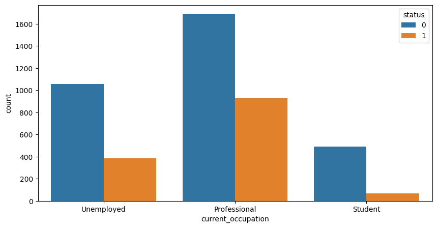

```python
plt.figure(figsize = (10, 5))
sns.countplot(x = 'current_occupation', hue = 'status', data = data)
plt.show()
```

**Answer:** From the above countplot, it can be seen that:

- The professional leads have the highest rate of conversion to sales
- Although, the unemployed leads could have the least rate of conversion because of their financial condition. But the real situation seems different. The students have the lowest rate of conversion to sales.
- By offering, student friendly budgets, the student groups can be attracted.

**Question 2: Do the first channels of interaction have an impact on the lead status?**

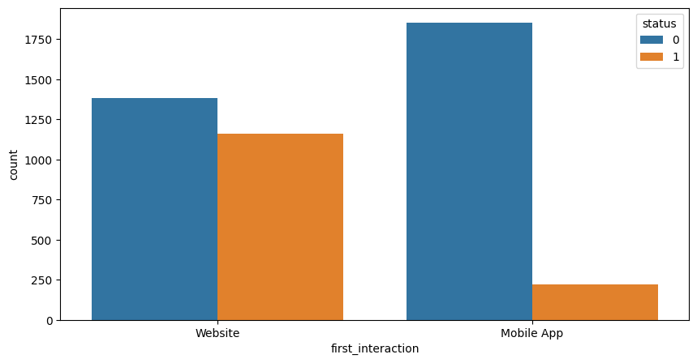

```python
plt.figure(figsize = (10, 5))
sns.countplot(x = 'first_interaction', hue = 'status', data = data)
plt.show()
```

**Answer:** Absolutely the first interaction certainly has a huge impact. The number of leads approached via Website were more compared to the Mobile App

**Question 3: Which way of interaction works best?**

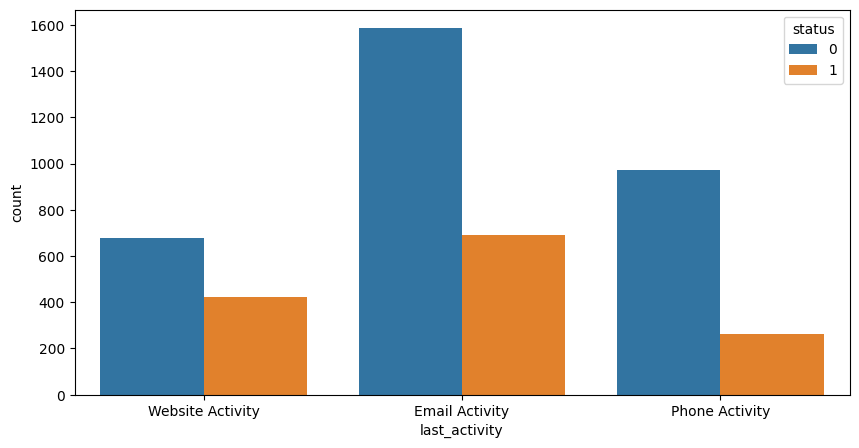

```python
plt.figure(figsize = (10, 5))
sns.countplot(x = 'last_activity', hue = 'status', data = data)
plt.show()
```

**Answer:** From the above countplot, it can be seen that, the conversion rate for website activity is the highest. So, the website works best

**Question 4: Which of these channels have the highest lead conversion rate?**

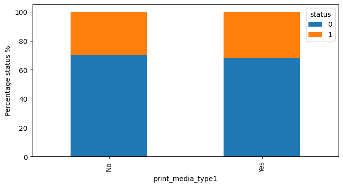

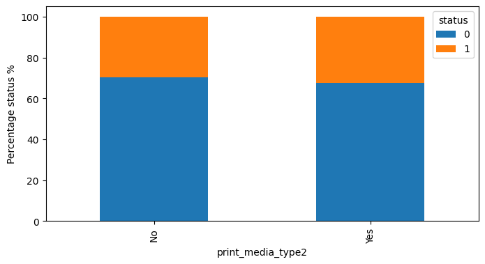

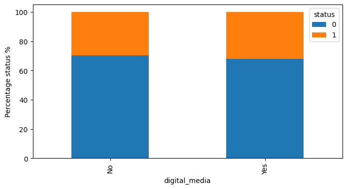

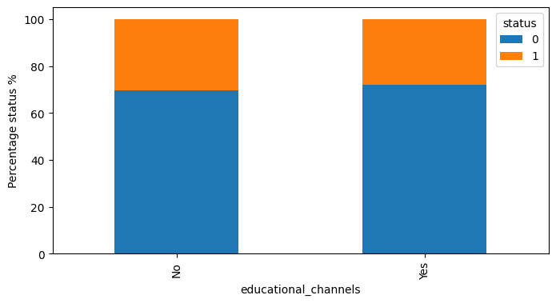

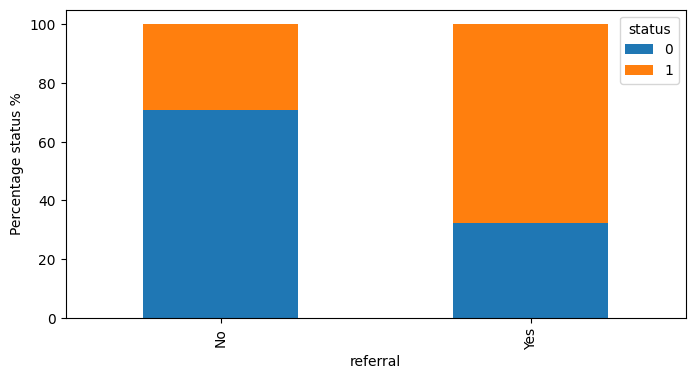

```python
def plot_percentage_status(data, cat_cols, status_col='status'):
    for col in cat_cols:
        if col != status_col:
            crosstab = pd.crosstab(data[col], data[status_col], normalize='index') * 100
            crosstab.plot(kind='bar', figsize=(8, 4), stacked=True)
            plt.ylabel('Percentage status %')
            plt.show()

cat_cols = ['print_media_type1', 'print_media_type2', 'digital_media', 'educational_channels', 'referral', 'status']
plot_percentage_status(data, cat_cols)
```

**Answer:** The leads from referrals have the highest conversion rate than the rest of the sources.

**Question 5: Does having more details about a prospect increase the chances of conversion?**

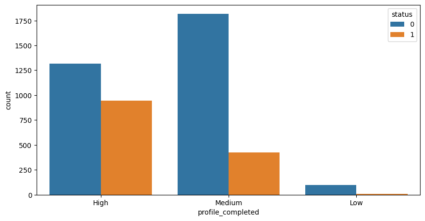

```python
plt.figure(figsize = (10, 5))
sns.countplot(x = 'profile_completed', hue = 'status', data = data)
plt.show()
```

**Answer:** It can be seen that the people who share high details about them tend to have the highest rate of conversion.

## Data Preprocessing

- Missing value treatment (if needed)
- Feature engineering (if needed)
- Outlier detection and treatment (if needed)
- Preparing data for modeling
- Any other preprocessing steps (if needed)

**1. There are no missing values.**

**2. The Feature Engineering process is given below:**

```python
X=data.drop(columns='status')
Y=data['status']

X = pd.get_dummies(X, drop_first=True)

X_train, X_test, y_train, y_test = train_test_split(X, Y, test_size=0.30, random_state=1)
```

**3. Outlier Detection and treatment:**

```python
q1 = data["website_visits"].quantile(0.90)
q2 = data["page_views_per_visit"].quantile(0.90)
df = df[df['website_visits'] < q1]
df = df[df['website_visits'] < q2]
print(df.shape)
```

```
(3715, 15)
```

**4. Data preparation: We will convert data types of integer columns to float**

```python
for column in ['age', 'website_visits', 'time_spent_on_website']:
    X_train[column]=X_train[column].astype('float')
    X_test[column]=X_test[column].astype('float')
```

## EDA

- It is a good idea to explore the data once again after manipulating it.

```python
print(X_train.isna().sum())
print('-'*50)
print(X_test.isna().sum())
```

```
age                               0
website_visits                    0
time_spent_on_website             0
page_views_per_visit              0
current_occupation_Student        0
current_occupation_Unemployed     0
first_interaction_Website         0
profile_completed_Low             0
profile_completed_Medium          0
last_activity_Phone Activity      0
last_activity_Website Activity    0
print_media_type1_Yes             0
print_media_type2_Yes             0
digital_media_Yes                 0
educational_channels_Yes          0
referral_Yes                      0
dtype: int64
--------------------------------------------------
age                               0
website_visits                    0
time_spent_on_website             0
page_views_per_visit              0
current_occupation_Student        0
current_occupation_Unemployed     0
first_interaction_Website         0
profile_completed_Low             0
profile_completed_Medium          0
last_activity_Phone Activity      0
last_activity_Website Activity    0
print_media_type1_Yes             0
print_media_type2_Yes             0
digital_media_Yes                 0
educational_channels_Yes          0
referral_Yes                      0
dtype: int64
```

## Building a Decision Tree model

```python
decision_tree = DecisionTreeClassifier(random_state = 1)
decision_tree.fit(X_train, y_train)
```

```
DecisionTreeClassifier(random_state=1)
```

```python
def metrics_score(actual, predicted):
    print(classification_report(actual, predicted))

    cm = confusion_matrix(actual, predicted)
    plt.figure(figsize=(10,5))

    sns.heatmap(cm, annot=True,  fmt='.2f', xticklabels=['Not Attrite', 'Attrite'], yticklabels=['Not Attrite', 'Attrite'])
    plt.ylabel('Actual')
    plt.xlabel('Predicted')
    plt.show()
```

**Checking performance on the training dataset:**

```
              precision    recall  f1-score   support

           0       1.00      1.00      1.00      2273
           1       1.00      1.00      1.00       955

    accuracy                           1.00      3228
   macro avg       1.00      1.00      1.00      3228
weighted avg       1.00      1.00      1.00      3228
```

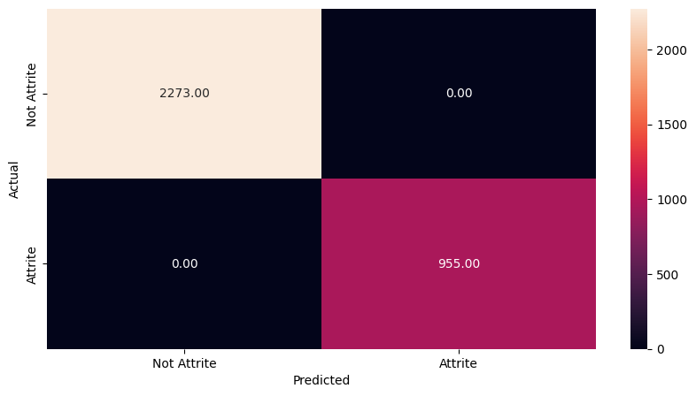

```python
y_train_pred_decision_tree = decision_tree.predict(X_train)
metrics_score(y_train, y_train_pred_decision_tree)
```

**Checking Performance on the test dataset**

```
              precision    recall  f1-score   support

           0       0.87      0.86      0.86       962
           1       0.69      0.70      0.70       422

    accuracy                           0.81      1384
   macro avg       0.78      0.78      0.78      1384
weighted avg       0.81      0.81      0.81      1384
```

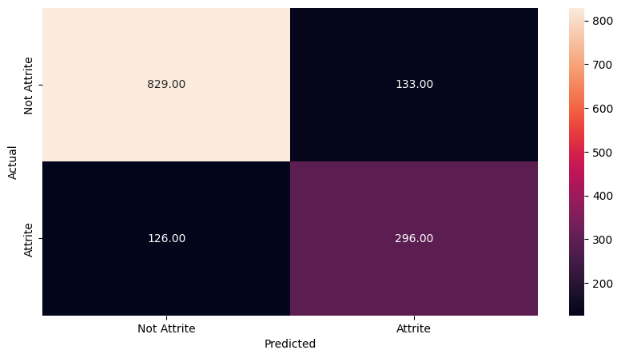

```python
y_test_pred_decision_tree = decision_tree.predict(X_test)
metrics_score(y_test, y_test_pred_decision_tree)
```

## Do we need to prune the tree?

```python
#Here are the feature importances
print (pd.DataFrame(decision_tree.feature_importances_, columns = ["Importance"], index = X_train.columns).sort_values(by = 'Importance', ascending = False))
```

```
                                Importance
time_spent_on_website             0.277845
first_interaction_Website         0.146368
page_views_per_visit              0.127103
profile_completed_Medium          0.124517
age                               0.087116
website_visits                    0.050957
current_occupation_Unemployed     0.040778
last_activity_Phone Activity      0.036790
current_occupation_Student        0.033281
last_activity_Website Activity    0.022535
profile_completed_Low             0.019435
digital_media_Yes                 0.009037
educational_channels_Yes          0.008055
print_media_type1_Yes             0.007751
referral_Yes                      0.005151
print_media_type2_Yes             0.003282
```

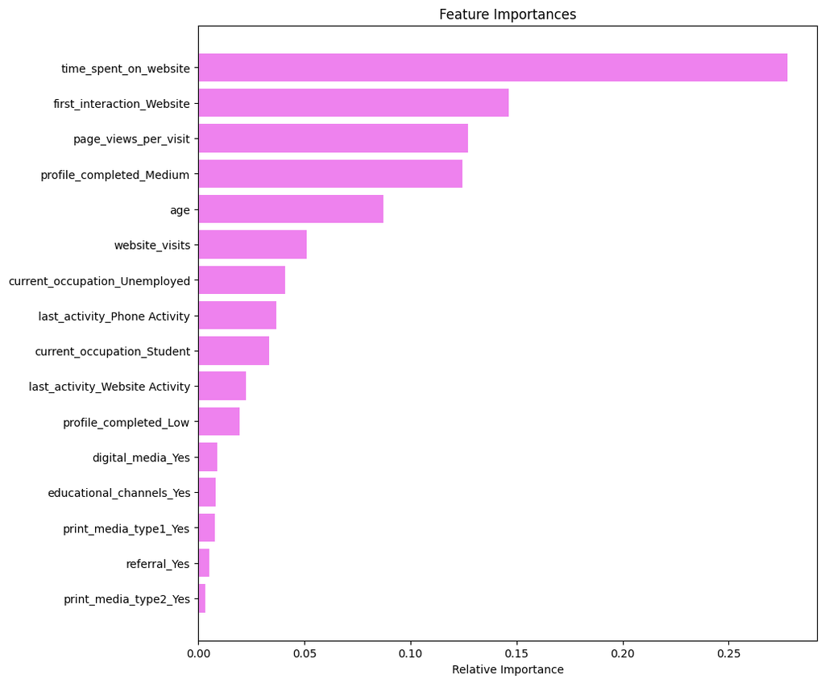

```python
features = list(X.columns)
importances = decision_tree.feature_importances_
indices = np.argsort(importances)

plt.figure(figsize = (10, 10))
plt.title('Feature Importances')
plt.barh(range(len(indices)), importances[indices], color = 'violet', align = 'center')
plt.yticks(range(len(indices)), [features[i] for i in indices])
plt.xlabel('Relative Importance')
plt.show()
```

As all the features contribute with different degrees, We need to find an optimal model.

```python
decision_tree_tuned = DecisionTreeClassifier(random_state = 7, class_weight = {0: 0.3, 1: 0.7})

parameters = {'max_depth': np.arange(2, 10),
              'criterion': ['gini', 'entropy'],
              'min_samples_leaf': [5, 10, 20, 25]
             }
scorer = metrics.make_scorer(recall_score, pos_label = 1)

grid_obj = GridSearchCV(decision_tree_tuned, parameters, scoring = scorer, cv = 5)

grid_obj = grid_obj.fit(X_train, y_train)

decision_tree_tuned = grid_obj.best_estimator_

decision_tree_tuned.fit(X_train, y_train)
```

```
DecisionTreeClassifier(class_weight={0: 0.3, 1: 0.7}, criterion='entropy',
                       max_depth=3, min_samples_leaf=5, random_state=7)
```

```
              precision    recall  f1-score   support

           0       0.94      0.77      0.85      2273
           1       0.62      0.88      0.73       955

    accuracy                           0.80      3228
   macro avg       0.78      0.83      0.79      3228
weighted avg       0.84      0.80      0.81      3228
```

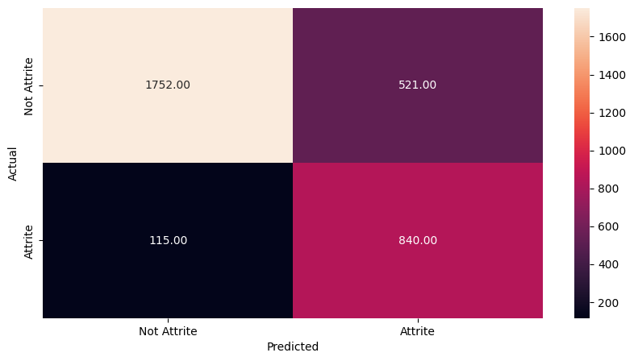

```python
# Checking performance on the training data
y_pred_train2 = decision_tree_tuned.predict(X_train)
metrics_score(y_train, y_pred_train2)
```

```
              precision    recall  f1-score   support

           0       0.93      0.77      0.84       962
           1       0.62      0.86      0.72       422

    accuracy                           0.80      1384
   macro avg       0.77      0.82      0.78      1384
weighted avg       0.83      0.80      0.80      1384
```

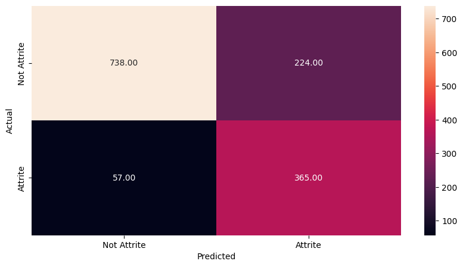

```python
# Checking performance on the test data
y_pred_test = decision_tree_tuned.predict(X_test)
metrics_score(y_test, y_pred_test)
```

```python
#Here are the feature importances
print (pd.DataFrame(decision_tree_tuned.feature_importances_, columns = ["Importance"], index = X_train.columns).sort_values(by = 'Importance', ascending = False))
```

```
                                Importance
time_spent_on_website             0.348142
first_interaction_Website         0.327181
profile_completed_Medium          0.239274
age                               0.063893
last_activity_Website Activity    0.021511
website_visits                    0.000000
page_views_per_visit              0.000000
current_occupation_Student        0.000000
current_occupation_Unemployed     0.000000
profile_completed_Low             0.000000
last_activity_Phone Activity      0.000000
print_media_type1_Yes             0.000000
print_media_type2_Yes             0.000000
digital_media_Yes                 0.000000
educational_channels_Yes          0.000000
referral_Yes                      0.000000
```

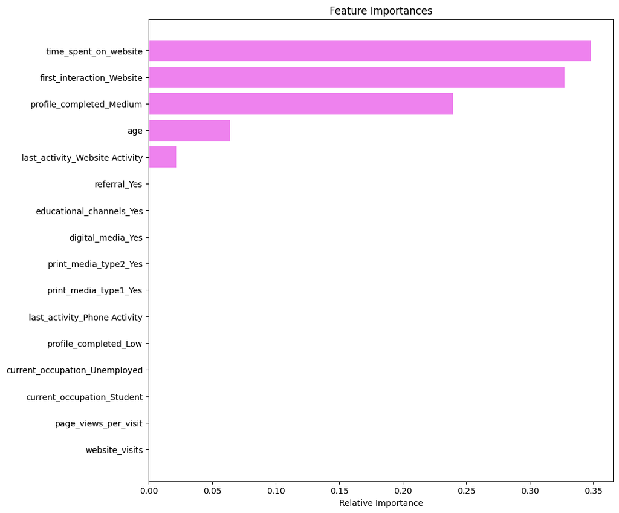

```python
features = list(X.columns)
importances = decision_tree_tuned.feature_importances_
indices = np.argsort(importances)

plt.figure(figsize = (10, 10))
plt.title('Feature Importances')
plt.barh(range(len(indices)), importances[indices], color = 'violet', align = 'center')
plt.yticks(range(len(indices)), [features[i] for i in indices])
plt.xlabel('Relative Importance')
plt.show()
```

```python
X_pruned = df[['time_spent_on_website', 'first_interaction', 'profile_completed', 'age', 'last_activity']]
```

From the above bservation, it can be said that 'time_spent_on_website', 'first_interaction', 'profile_completed', 'last_activity', 'age' contribute to the model. The rest of the model does not impact the model. So we can prune them.

## Building a Random Forest model

```python
# Fitting the Random Forest classifier on the training data
random_forest_estimator = RandomForestClassifier(class_weight = {0: 0.15, 1: 0.85}, random_state = 1)
random_forest_estimator.fit(X_train, y_train)
```

```
RandomForestClassifier(class_weight={0: 0.15, 1: 0.85}, random_state=1)
```

```
              precision    recall  f1-score   support

           0       1.00      1.00      1.00      2273
           1       1.00      1.00      1.00       955

    accuracy                           1.00      3228
   macro avg       1.00      1.00      1.00      3228
weighted avg       1.00      1.00      1.00      3228
```

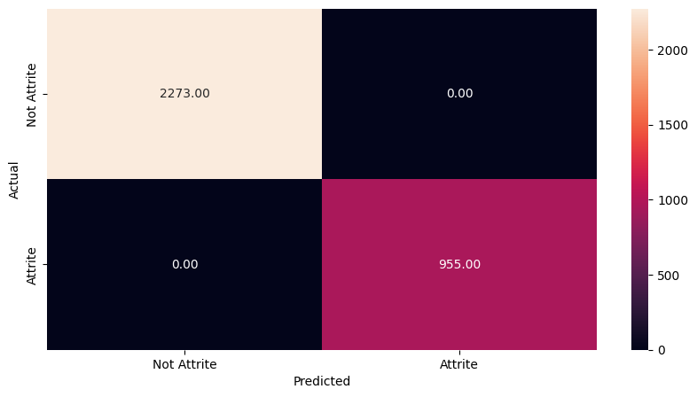

```python
# Checking performance on the training data
y_pred_train_random_forest = random_forest_estimator.predict(X_train)
metrics_score(y_train, y_pred_train_random_forest)
```

```
              precision    recall  f1-score   support

           0       0.87      0.93      0.90       962
           1       0.80      0.67      0.73       422

    accuracy                           0.85      1384
   macro avg       0.84      0.80      0.81      1384
weighted avg       0.85      0.85      0.85      1384
```

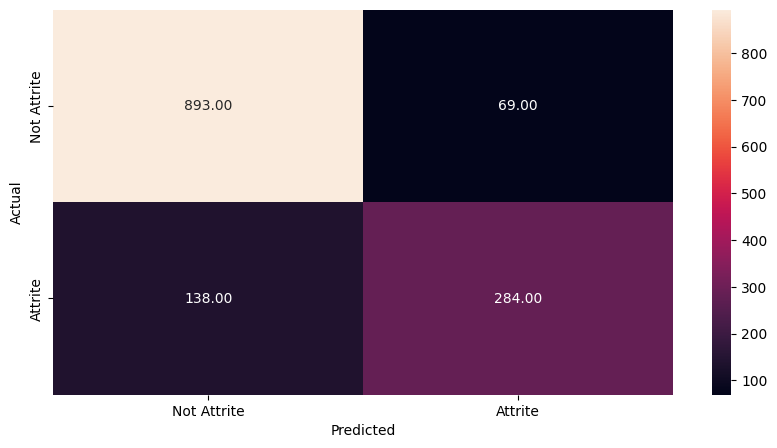

```python
# Checking performance on the test data
y_pred_train_random_forest = random_forest_estimator.predict(X_test)
metrics_score(y_test, y_pred_train_random_forest)
```

So, from the above test and training data, it can be easily said that Random Forest Classifier works better than Decision Tree Classifier, although it is overfitting.

## Do we need to prune the tree?

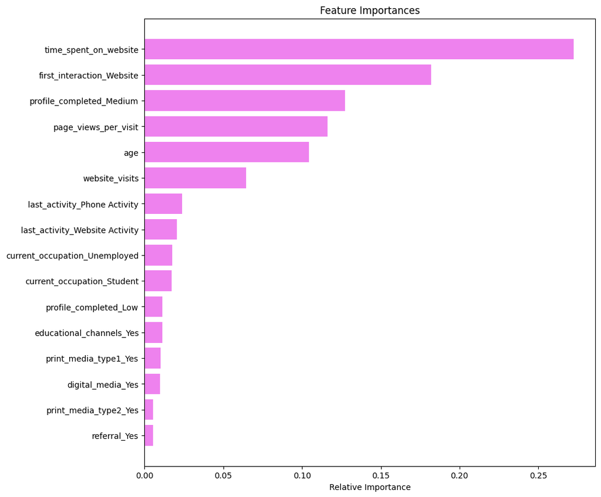

```python
importances = random_forest_estimator.feature_importances_
indices = np.argsort(importances)
feature_names = list(X.columns)

plt.figure(figsize = (10, 10))
plt.title('Feature Importances')
plt.barh(range(len(indices)), importances[indices], color = 'violet', align = 'center')
plt.yticks(range(len(indices)), [feature_names[i] for i in indices])
plt.xlabel('Relative Importance')
plt.show()
```

It can be seen that all the features contribute to the model.

```python
# Choose the type of classifier
random_forest_estimator_tuned = RandomForestClassifier(criterion = "entropy", random_state = 2)

# Grid of parameters to choose from
parameters = {"n_estimators": [110, 120],
    "max_depth": [6, 7],
    "min_samples_leaf": [20, 25],
    "max_features": [0.8, 0.9],
    "max_samples": [0.9, 1],
    "class_weight": ["balanced",{0: 0.3, 1: 0.7}]
             }

# Type of scoring used to compare parameter combinations - recall score for class 1
scorer = metrics.make_scorer(recall_score, pos_label = 1)

# Run the grid search on the training data using scorer=scorer and cv=5
grid_obj = GridSearchCV(random_forest_estimator_tuned, parameters, scoring = scorer, cv = 5)

grid_obj = grid_obj.fit(X_train, y_train)

# Save the best estimator to variable rf_estimator_tuned
random_forest_estimator_tuned = grid_obj.best_estimator_
```

```python
# Fitting the best algorithm to the training data
random_forest_estimator_tuned.fit(X_train, y_train)
```

```
RandomForestClassifier(class_weight='balanced', criterion='entropy',
                       max_depth=6, max_features=0.8, max_samples=0.9,
                       min_samples_leaf=20, n_estimators=110, random_state=2)
```

```
              precision    recall  f1-score   support

           0       0.94      0.84      0.89      2273
           1       0.69      0.88      0.77       955

    accuracy                           0.85      3228
   macro avg       0.82      0.86      0.83      3228
weighted avg       0.87      0.85      0.85      3228
```

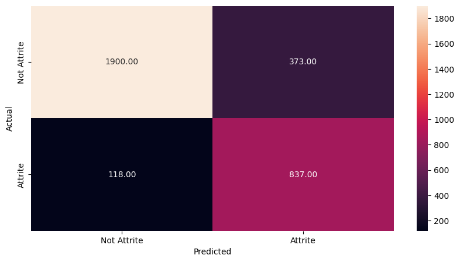

```python
# Checking performance on the training dataset
y_train_pred_decision_tree = random_forest_estimator_tuned.predict(X_train)
metrics_score(y_train, y_train_pred_decision_tree)
```

```
              precision    recall  f1-score   support

           0       0.93      0.83      0.88       962
           1       0.69      0.85      0.76       422

    accuracy                           0.84      1384
   macro avg       0.81      0.84      0.82      1384
weighted avg       0.86      0.84      0.84      1384
```

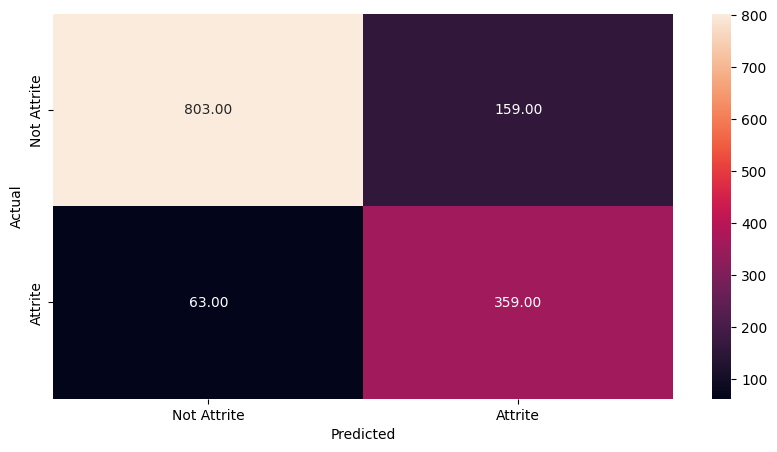

```python
# Checking performance on the test dataset
y_test_pred_decision_tree = random_forest_estimator_tuned.predict(X_test)
metrics_score(y_test, y_test_pred_decision_tree)
```

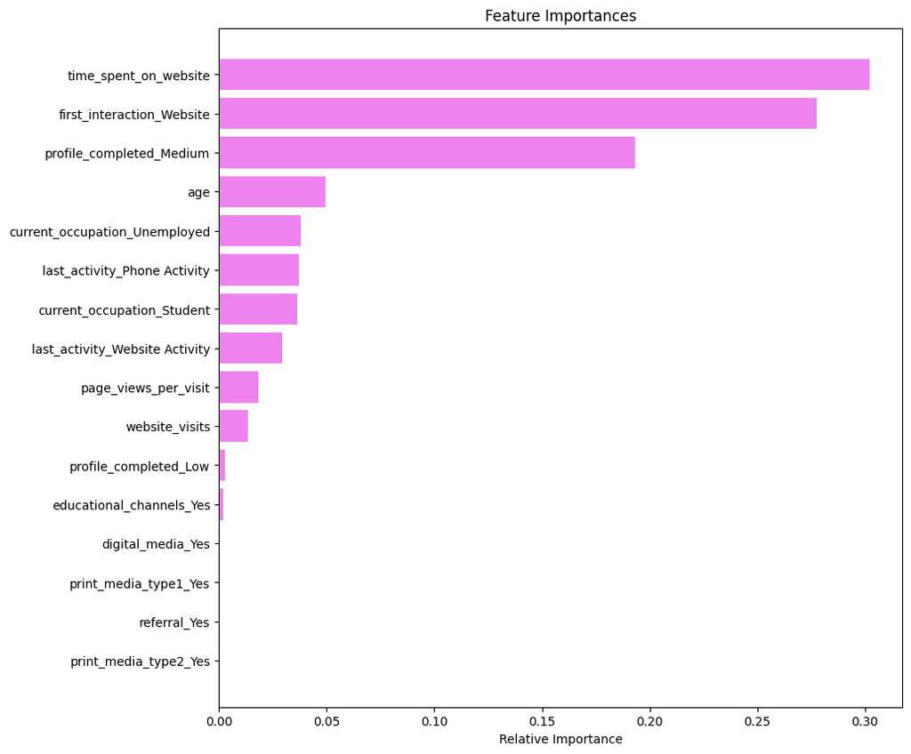

```python
#Feature importance of the model
importances = random_forest_estimator_tuned.feature_importances_
indices = np.argsort(importances)
feature_names = list(X.columns)

plt.figure(figsize = (10, 10))
plt.title('Feature Importances')
plt.barh(range(len(indices)), importances[indices], color = 'violet', align = 'center')
plt.yticks(range(len(indices)), [feature_names[i] for i in indices])
plt.xlabel('Relative Importance')
plt.show()
```

print media type1, print media type2, digital media, and referral do not contribute.So, we prune them.

```python
X_pruned_random_forest = df[['time_spent_on_website', 'first_interaction', 'profile_completed', 'age', 'current_occupation',
                  'last_activity', 'page_views_per_visit', 'website_visits', 'educational_channels']]
```